# Data Task

University of Chicago Booth PREDOC

Author

Sheena Tan

Published

February 22, 2024

**Github Repo Link**

https://github.com/sheena-tan/data-task

# Introduction

This project uses data provided by the University of Chicago Booth School of Business as part of a data task for a pre-doctoral research position. The data is from a study aiming to understand how the presence or absence of a return apology can affect the way that people feel, and whether these affects vary as a result of one’s willingness to apologize first.

## Data Cleaning

A glimpse of the data reveals that all respondents (*N = 61*) consented to participate. Removing participants that did not complete the majority of the survey, give legitimate responses, or pass the attention check resulted in *N = 46* total participants.

```r
apology_data <- read_csv(here("data/apology_data.csv"))

skimr::skim(apology_data)
# consent: n_unique = 1; all responses agreed
# passedattn: n_unique = 2; need to clean responses that did not pass
# Progress: mean = 84.1; need to clean responses that did not answer about feelings

## data cleaning ----
apology_clean <- apology_data |>
  filter(ResponseId != "R_bBJ75JWs3W8KSgF") |> #see comments field
  filter(Progress > 30) |>
  filter(passedattn == "yes") |>
  select(ResponseId, initiator_type, starts_with("feelings_"), starts_with("outcome_"),
         blame_1, real_imaginary, describe, comments)
```

# Task 1

## Initial Data Exploration

There definitely seems to be a significant difference between the feelings of those who do and don’t receive return apologies, with the IQR jumping from about (-30,-10) without to (0,20) with. In other words, people feel very bad when they do not get a return apology but feel much better when they do.

I wonder if these results map onto *agreeableness* as a personality trait then, though everything is likely heavily dependent on by people’s lived experiences.

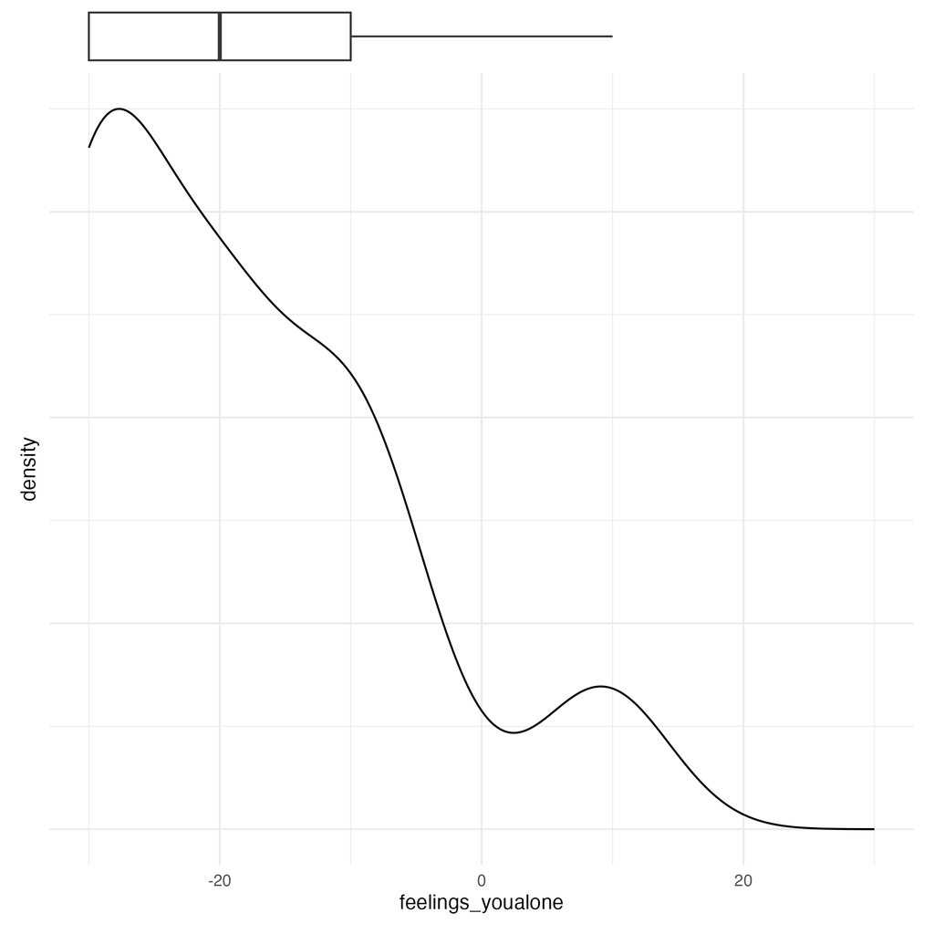

(a) Overall - Apology not returned

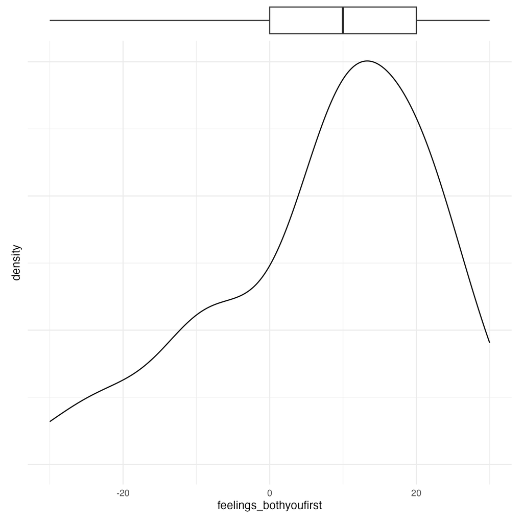

(b) Overall - Apology returned

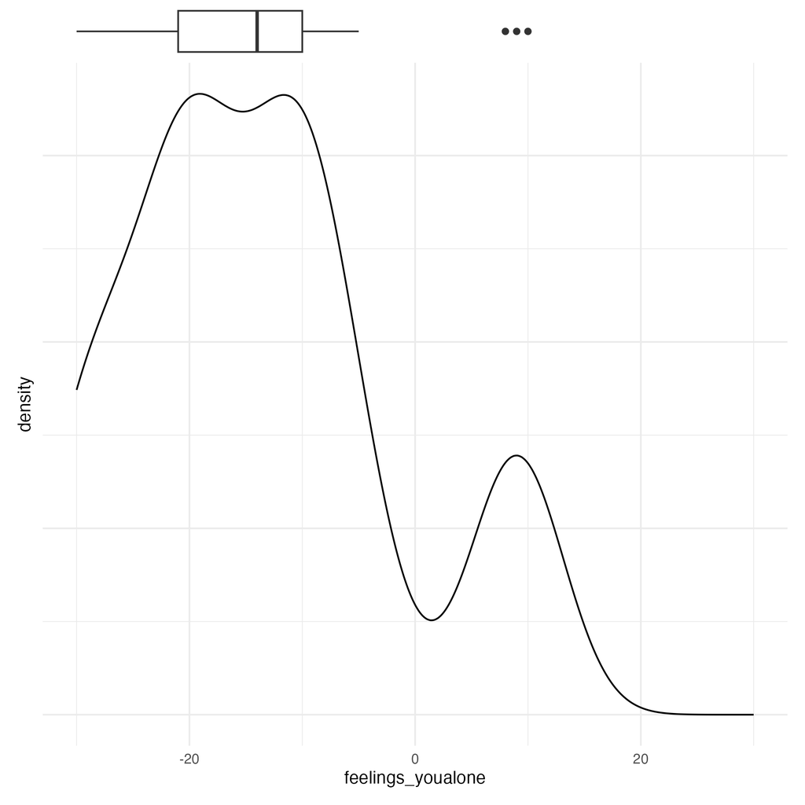

(c) Always - Apology not returned

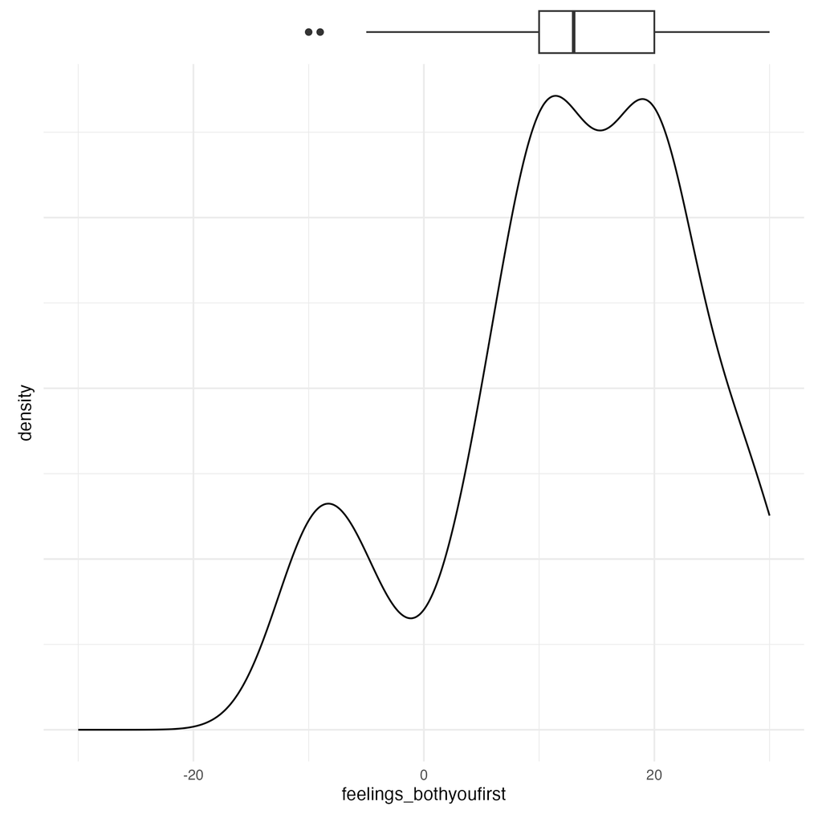

(d) Always - Apology returned

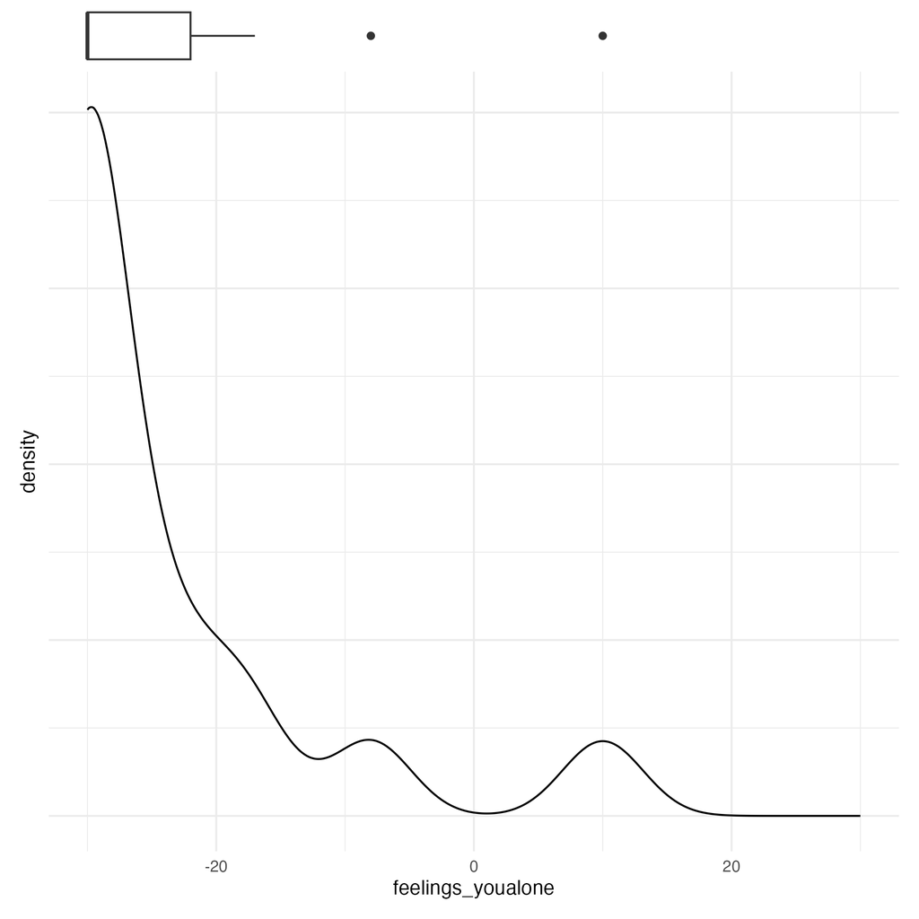

(e) Conditional - Apology not returned

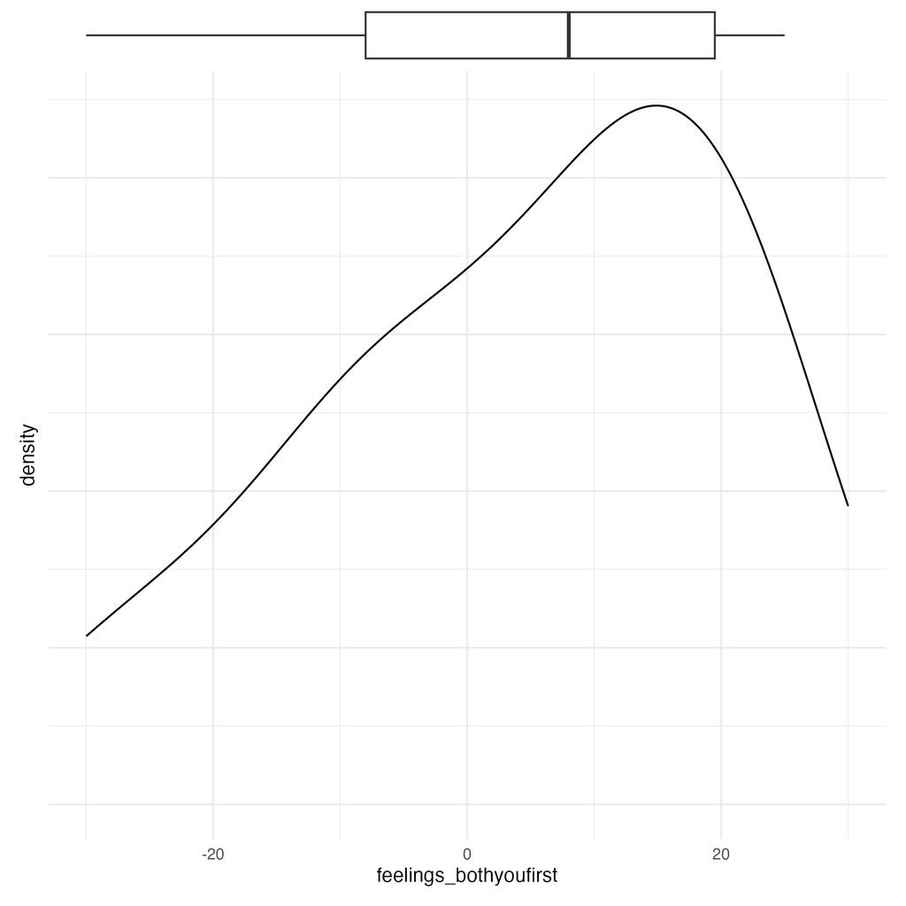

(f) Conditional - Apology returned

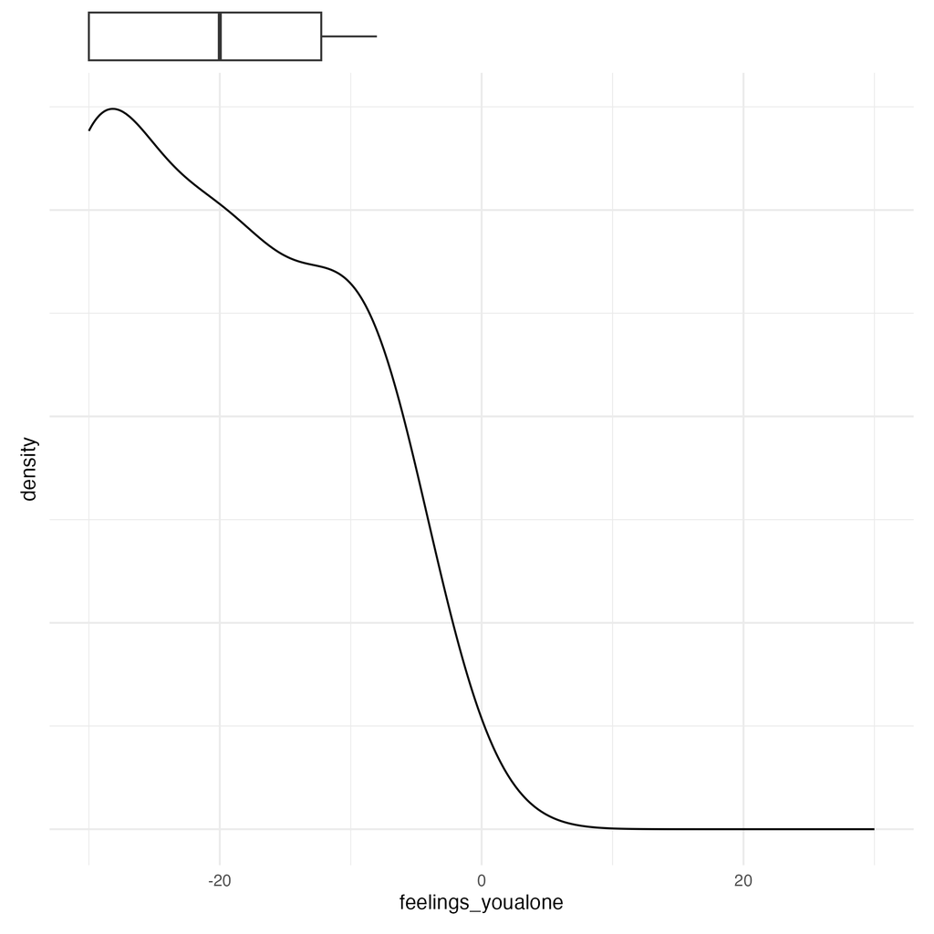

(g) Never - Apology not returned

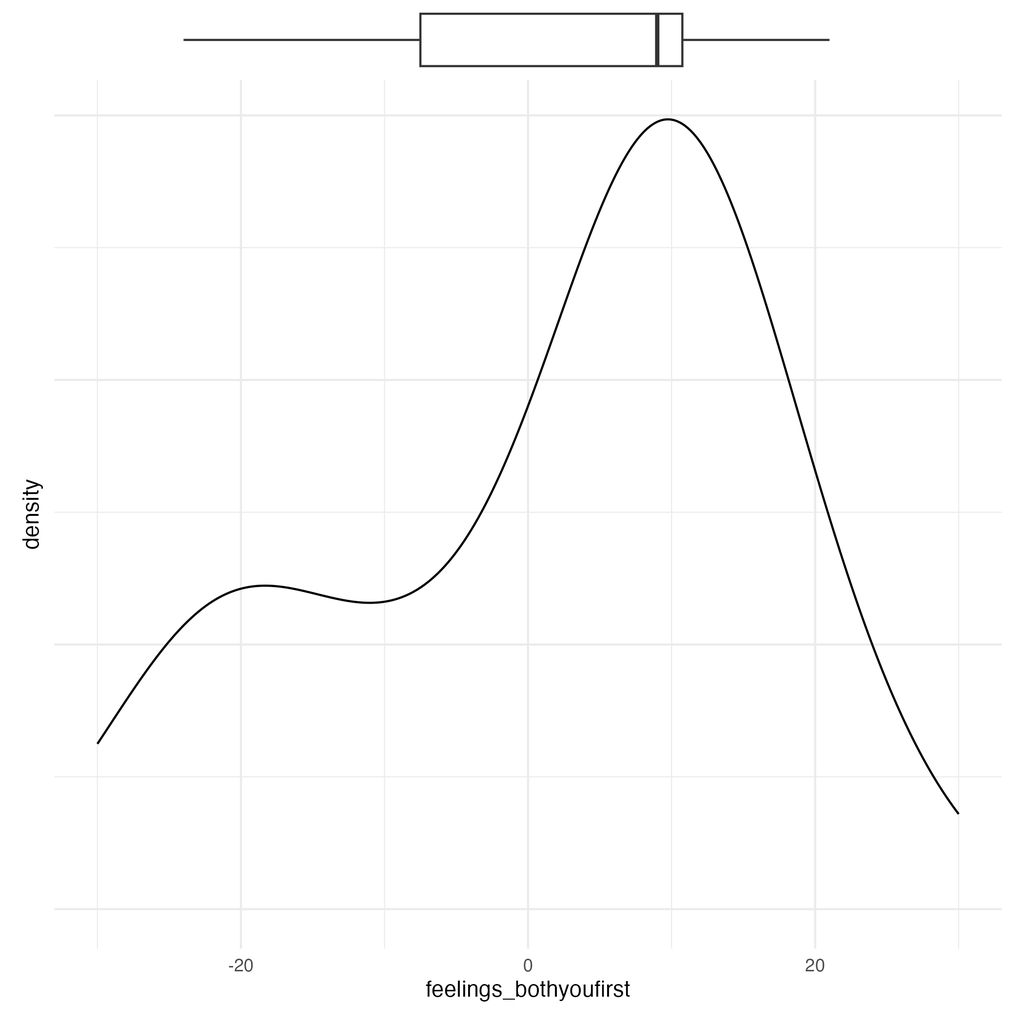

(h) Never - Apology returned

Figure 1: Feeling ratings by initiator type after (not) receiving a return apology

```r
# code for reproducibility
plot_density_boxplot <- function(data, x_variable) {
  p1 <- ggplot(data, aes({{x_variable}})) +
    geom_boxplot() +
    xlim(-30, 30) +
    theme_void()

  p2 <- ggplot(data, aes({{x_variable}})) +
    geom_density() +
    xlim(-30, 30) +
    theme_minimal() +
    theme(
      axis.text.y = element_blank(),
      axis.ticks.y = element_blank()
    )

  p1/p2 + plot_layout(heights = unit(c(1, 5), c("cm", "null")))
}

alone_total <- plot_density_boxplot(apology_clean, feelings_youalone)
both_total <- plot_density_boxplot(apology_clean, feelings_bothyoufirst)

alone_always <- apology_clean |> filter(initiator_type == "always") |>
  plot_density_boxplot(feelings_youalone)
both_always <- apology_clean |> filter(initiator_type == "always") |>
  plot_density_boxplot(feelings_bothyoufirst)

alone_cond <- apology_clean |> filter(initiator_type == "conditional") |>
  plot_density_boxplot(feelings_youalone)
both_cond <- apology_clean |> filter(initiator_type == "conditional") |>
  plot_density_boxplot(feelings_bothyoufirst)

alone_never <- apology_clean |> filter(initiator_type == "never") |>
  plot_density_boxplot(feelings_youalone)
both_never <- apology_clean |> filter(initiator_type == "never") |>
  plot_density_boxplot(feelings_bothyoufirst)
```

## Question 1

*Do people care about getting a return apology after being the first to apologize?*

We define “whether people care” about getting a return apology as a significant difference in emotional response within participants between the two apology scenarios – not getting (`feelings_youalone`) and getting (`feelings_bothyoufirst`) a return apology. As the sample is sufficiently large, a paired samples t-test was conducted to compare the two scenarios.

```r
# transform data for pairwise t-test
apology_long <- apology_clean |>
  select(ResponseId, feelings_youalone, feelings_bothyoufirst) |>
  rename(no = feelings_youalone, yes = feelings_bothyoufirst) |>
  pivot_longer(cols = c("no", "yes"), names_to = "apology_returned") |>
  arrange(apology_returned, ResponseId)

# summary statistics
apology_long |> group_by(apology_returned) |>
  summarize(
    count = n(),
    mean = mean(value, na.rm = TRUE),
    sd = sd(value, na.rm = TRUE)
  )

# pairwise t-test
t.test(value ~ apology_returned, apology_long, paired = TRUE)
```

Participants responded significantly more negatively when not receiving a return apology (*M* = -18.3, *SD* = 11.9) than when they did receive one (*M* = 7.54, *SD* = 14.4), *t*(45) = -12.58, *p* < .001, 95% CI [-30.01, -21.73].

**Answer:** Yes, people do not like when they do not receive a return apology. We can be 95% confident that the true difference between emotional responses is approximately 30 to 22 points more negative for those who do not receive a return apology than those who do.

## Question 2

*Does this difference vary as function of individual differences in initiator type?*